# Targeting Housing Subsidy with People-Based Machine Learning

Emily Zhou

2023-10-28

Version 1.0 | First Created Oct 22, 2023 | Updated Nov 1, 2023

Keywords: Logistic Regression, Confusion Matrix, ROC Curve, Sensitivity, Specificity, Cost-Benefit Analysis, McFadden R-Squared

# Introduction

People-based machine learning, a field harnessing the power of data-driven insights into human behaviors and preferences, has become pivotal for businesses and organizations. With algorithms trained on human-centric data, businesses get to personalize products, services, and experiences based on individual customer preferences. At any point, the bottom line of any businesses and organizations may be affected, if a client no longer wish to participate, donate, or purchase a good, which makes it extra important to have a predictive model that captures these potential changes. Like any machine learning applications, however, it is difficult to capture the nuances in human behavior with a single model, nor is it possible to have a unbiased sample dataset that truly reflect human behavior. This means that continuous model adaptation and recognition of these complexities are essential for effective decision-making based on these models.

The goal of this report is to fit a logistic regression model to predict whether homeowners in Emil City will enter and take a home repair tax credit. To contextualize, the city is considering a more proactive approach for targeting homeowners who would quality for this tax credit program and the Department of Housing and Community Development (HCD) have been trying to proactively reach out to eligible homeowners ever year. It is predicted that houses that transacted after taking the credit, will sell with a $10,000 premium, on average. Homes surrounding the repaired home see an aggregate premium of $56,000, on average. The thorny task for the HCD is to target homeowners with the highest likelihood of accepting the credit. In this case, they could maximize the benefits of the aggregate premium of houses while reduce the marketing resources cost. As of now, typically not all eligible homeowners they reach out and enter the program ultimately takes the credit.

That said, we will need to train a better model to ensure that the HCD will not be reaching out to eligible homeowners at random. Logistic regression is used here due to its interpretability and suitability for binary classification problems (in this case, our dependent variable indicate whether the a homeowner will take the credit or not). We will **first** start with data exploration to determine variables most explains homeowner’s behavior. **Then**, we split the data into training and testing set, fit a regression model, and constructed confusion matrix at 50% threshold to see the extent to which our model can correctly predict homeowner entering the credit program (true positive), or correctly predict homeowner not taking the credit (true negative). This is **followed** by a cross validation test to compute ROC, sensitivity, and specificity. We **conclude** our analysis with a cost/benefit analysis and determine the optimal threshold of delineating positive and negative prediction that would maximize the revenue.

The GitHub repository for this report is [here](https://github.com/emilyzhou112/MUSA5080-Housing-Subsidy).

# Variables Examination

The first part of this report focuses on data exploration to see how each factor in our dataset relates to homeowner’s decision to accept home repair tax credit. Variables are split into categorical variables and numeric variables respectively, for which we conducted chi-square and anova tests to examine if there’s a significant association between dependent variable and independent variables.

## Categorical Variables

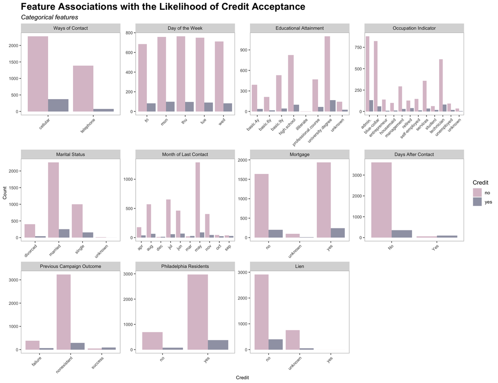

```r
cat_var <- housing %>%
  select(-c(X, age, y_numeric, previous, unemploy_rate, cons.price.idx, cons.conf.idx, inflation_rate, spent_on_repairs, campaign))
cat_var %>%
    gather(Variable, value, -y) %>%
    count(Variable, value, y) %>%
      ggplot(., aes(value, n, fill = y)) +
        geom_bar(position = "dodge", stat="identity") +
        facet_wrap(~Variable, scales="free", ncol = 4,
                   labeller= labeller(Variable = c(
                     `contact` = "Ways of Contact",
                     `day_of_week` = "Day of the Week",
                     `education` = "Educational Attainment",
                     `pdays` = "Days After Contact",
                     `job` = "Occupation Indicator",
                     `marital` = "Marital Status",
                     `month` = "Month of Last Contact",
                     `mortgage` = "Mortgage",
                     `poutcome` = "Previous Campaign Outcome",
                     `taxbill_in_phl` = "Philadelphia Residents",
                     `taxLien` = "Lien"))) +
        scale_fill_manual(values = palette2, name = "Credit") +
        labs(x="Credit", y="Count",
             title = "Feature Associations with the Likelihood of Credit Acceptance",
             subtitle = "Categorical features") +
        theme(axis.text.x = element_text(angle = 45, hjust = 1)) +
  theme(plot.subtitle = element_text(size = 12,face = "italic"),
        plot.title = element_text(size = 18, face = "bold"),
        axis.text.x=element_text(size=8),
        axis.text.y=element_text(size=8),
        axis.title=element_text(size=9),
        panel.background = element_blank(),
        panel.border = element_rect(colour = "grey", fill=NA, linewidth =0.8))
```

Using pure visual evidence is not enough to explain the significance of our categorical variables in predicting whether homeowners will take the credit. To support the above visualization, we conducted chi-square test iteratively for all categorical variables. The chi-square test determines if there is a significant association between categorical variables. It compares the observed frequencies of different categories in a contingency table with the frequencies that would be expected if the variables were independent. The table below shows that `Ways of Contact`, `Edcucation`, `Marital`, `Occupation`, `Month of Last Contact`, `Previoust Campaign Outcome`, `Lien Presence` and `Days After Last Contact` are significant predictors in determining homeowner’s likelihood of accepting the credit.

```r
chi_var <- c("contact", "day_of_week", "education", "job", "marital", "month", "mortgage", "poutcome", "taxbill_in_phl", "taxLien", "pdays")

Label = c("contact" = "Ways of Contact",
          "day_of_week" = "Day of the Week",
          "education" = "Educational Attainment",
          "job" = "Occupation Indicator",
          "marital" = "Marital Status",
          "month" = "Month of Last Contact",
          "mortgage" = "Mortgage",
          "poutcome" = "Previous Campaign Outcome",
          "taxbill_in_phl" = "Philadelphia Residents",
          "taxLien" = "Lien",
          "pdays" = "Days After Contact")

chi_square_results <- data.frame(
  Df = integer(),
  X_Squared = numeric(),
  P_Value = numeric(),
  stringsAsFactors = FALSE
)

for (var in chi_var) {
  contingency_table <- table(cat_var$y, cat_var[[var]])
  chi_square <- chisq.test(contingency_table)
  chi_square_results <- rbind(chi_square_results, data.frame(
    Df = chi_square$parameter,
    X_Squared = chi_square$statistic,
    P_Value = chi_square$p.value
  ))
}

rownames(chi_square_results) <- Label


chi_square_results %>%
 kable() %>%
 kable_styling( bootstrap_options = c("striped", "hover", "condensed")) %>%
    footnote(general_title = "\n", general = "Table 1")
```

|  | Df | X_Squared | P_Value |
| --- | --- | --- | --- |
| Ways of Contact | 1 | 76.8462374 | 0.0000000 |
| Day of the Week | 4 | 0.5121761 | 0.9723049 |
| Educational Attainment | 7 | 22.2918199 | 0.0022621 |
| Occupation Indicator | 11 | 69.9786737 | 0.0000000 |
| Marital Status | 3 | 10.2859188 | 0.0162857 |
| Month of Last Contact | 9 | 299.7881167 | 0.0000000 |
| Mortgage | 2 | 0.6273842 | 0.7307440 |
| Previous Campaign Outcome | 2 | 454.4865243 | 0.0000000 |
| Philadelphia Residents | 1 | 0.7595710 | 0.3834628 |
| Lien | 2 | 24.1856637 | 0.0000056 |
| Days After Contact | 1 | 448.2212094 | 0.0000000 |

Table 1

## Numeric Variables

The figure below shows the difference in the number of homeowners who accepted and did not accept tax credit based on a different numeric features. There seems to be a significant difference in the number of people accepting credit based on their age, number of contacts for this campaign and before this campaign, as well as inflation and unemployment rate of that time.

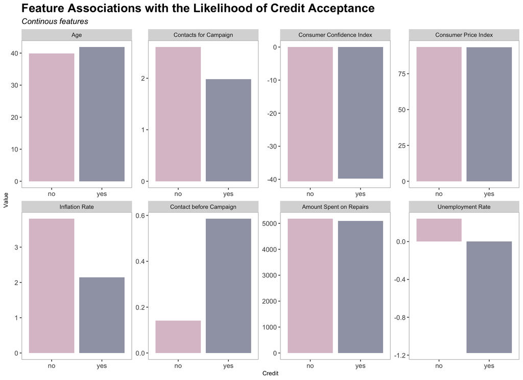

```r
numeric_var <- housing %>%
  select(age, y, previous, unemploy_rate, cons.price.idx, cons.conf.idx, inflation_rate, spent_on_repairs, campaign)


numeric_var %>%
  gather(Variable, value, -y) %>%
    ggplot(aes(y, value, fill=y)) +
      geom_bar(position = "dodge", stat = "summary", fun = "mean") +
      facet_wrap(~Variable, scales = "free", ncol = 4, labeller= labeller(Variable = c(
                     `age` = "Age",
                     `previous` = "Contact before Campaign",
                     `unemploy_rate` = "Unemployment Rate",
                     `cons.price.idx` = "Consumer Price Index",
                     `cons.conf.idx` = "Consumer Confidence Index",
                     `campaign` = "Contacts for Campaign",
                     `inflation_rate` = "Inflation Rate",
                     `spent_on_repairs` = "Amount Spent on Repairs"))) +
      scale_fill_manual(values = palette2) +
      labs(x="Credit", y="Value",
           title = "Feature Associations with the Likelihood of Credit Acceptance",
           subtitle = "Continous features") +
      theme(legend.position = "none") +
    theme(plot.subtitle = element_text(size = 12,face = "italic"),
        plot.title = element_text(size = 18, face = "bold"),
        axis.text.x=element_text(size=10),
        axis.text.y=element_text(size=10),
        axis.title=element_text(size=9),
        panel.background = element_blank(),
        panel.border = element_rect(colour = "grey", fill=NA, linewidth =0.8))
```

Because these numeric features all have different scales and are difficult to compare across, we made another density plot, which conveys the same information, but shows distribution of a continuous variable. Surprisingly, we see that the distribution of `Consumer Confidence Index`, `Consumer Price Index`, and `Amount Spent on Repairs` all significantly differ between homeowners who accepted and did not accept the tax credit.

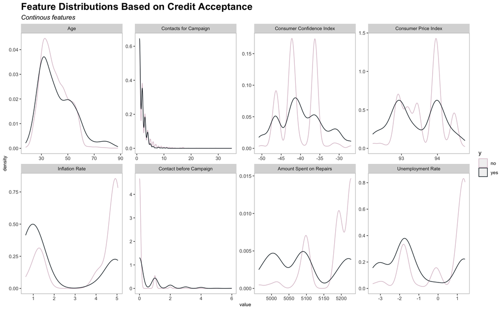

```r
numeric_var %>%
    gather(Variable, value, -y) %>%
    ggplot() +
    geom_density(aes(value, color=y), fill = "transparent") +
   facet_wrap(~Variable, scales = "free", ncol = 4, labeller= labeller(Variable = c(
                     `age` = "Age",
                     `previous` = "Contact before Campaign",
                     `unemploy_rate` = "Unemployment Rate",
                     `cons.price.idx` = "Consumer Price Index",
                     `cons.conf.idx` = "Consumer Confidence Index",
                     `inflation_rate` = "Inflation Rate",
                     `campaign` = "Contacts for Campaign",
                     `spent_on_repairs` = "Amount Spent on Repairs")))+
  scale_color_manual(values = palette1) +
    labs(title = "Feature Distributions Based on Credit Acceptance",
         subtitle = "Continous features") +
  theme(plot.subtitle = element_text(size = 12,face = "italic"),
        plot.title = element_text(size = 18, face = "bold"),
        axis.text.x=element_text(size=9),
        axis.text.y=element_text(size=9),
        axis.title=element_text(size=9),
        panel.background = element_blank(),
        panel.border = element_rect(colour = "grey", fill=NA, linewidth =0.8))
```

We further conducted ANOVA test for all numeric features to see if there’s a significant difference in mean age, for example, across people who take and did not take the credit. The result is in concur with our expectations: all numeric variables are significant predictors.

```r
anova_var <- c("age", "previous", "unemploy_rate", "cons.price.idx", "cons.conf.idx", "inflation_rate", "spent_on_repairs", "campaign")

new_names <- c("age" = "Age",
                "previous" = "Contact before Campaign",
                "unemploy_rate" = "Unemployment Rate",
                "cons.price.idx" = "Consumer Price Index",
                "cons.conf.idx" = "Consumer Confidence Index",
                "inflation_rate" = "Inflation Rate",
                "spent_on_repairs" = "Amount Spent on Repairs",
               "campaign" = "Contacts for Campaign")

anova_results <- data.frame(
                            Df = integer(),
                            Sum_Sq = numeric(),
                            Mean_Sq = numeric(),
                            F_value = numeric(),
                            P_Value = numeric(), stringsAsFactors = FALSE)

for (var in anova_var) {
  anova_result <- aov(numeric_var[[var]] ~ numeric_var$y)
  summary_data <- summary(anova_result)[[1]][, c("Df", "Sum Sq", "Mean Sq", "F value", "Pr(>F)")][1:1, ]
  anova_results <- rbind(anova_results, summary_data)
}


rownames(anova_results) <- new_names


anova_results %>%
 kable() %>%
 kable_styling(bootstrap_options = c("striped", "hover", "condensed")) %>%
    footnote(general_title = "\n", general = "Table 2")
```

|  | Df | Sum Sq | Mean Sq | F value | Pr(>F) |
| --- | --- | --- | --- | --- | --- |
| Age | 1 | 1596.56982 | 1596.56982 | 15.06149 | 0.0001057 |
| Contact before Campaign | 1 | 79.03066 | 79.03066 | 288.00244 | 0.0000000 |
| Unemployment Rate | 1 | 807.05379 | 807.05379 | 359.02715 | 0.0000000 |
| Consumer Price Index | 1 | 13.36299 | 13.36299 | 40.19177 | 0.0000000 |
| Consumer Confidence Index | 1 | 257.19577 | 257.19577 | 12.21670 | 0.0004786 |
| Inflation Rate | 1 | 1103.20812 | 1103.20812 | 402.90944 | 0.0000000 |
| Amount Spent on Repairs | 1 | 2725800.03197 | 2725800.03197 | 571.90285 | 0.0000000 |
| Contacts for Campaign | 1 | 157.25175 | 157.25175 | 23.97551 | 0.0000010 |

Table 2

# Logistic Regression

We then fit a logistic regression containing all variables in our dataset. To do so, we split our data randomly into 65% of training dataset and 35% of testing dataset. Some of our variables, such as Lien and Education, have single occurrence and therefore needs to be put into the training set to avoid new levels appearing in the testing set. This model shows that some indicators are significantly correlated with credit acceptance with p < 0.05. This include age, some categories of job, ways of contact, month last contacted, previous campaign outcome, unemployment rate, consumer price and confidence indices. However, the majority of predictors are not significant.

```r
set.seed(479)
trainIndex <- createDataPartition(y = paste(housing$taxLien, housing$education) , p = .65,
                                  list = FALSE,
                                  times = 1)
housingTrain <- housing[ trainIndex,]
housingTest  <- housing[-trainIndex,]

housingModel <- glm(y_numeric ~ .,
                  data=housingTrain %>%
                    dplyr::select(age, job, marital, education, taxLien, mortgage, taxbill_in_phl, contact, month, day_of_week, campaign, pdays, poutcome, unemploy_rate, cons.conf.idx, cons.price.idx, inflation_rate, spent_on_repairs, y_numeric), family="binomial" (link="logit"))

housing_sum <- summary(housingModel)
coefficients_table <- as.data.frame(housing_sum$coefficients)

coefficients_table$significance <- ifelse(coefficients_table$`Pr(>|z|)` < 0.001, '***',
                                         ifelse(coefficients_table$`Pr(>|z|)` < 0.01, '**',
                                                ifelse(coefficients_table$`Pr(>|z|)` < 0.05, '*',
                                                       ifelse(coefficients_table$`Pr(>|z|)` < 0.1, '.', ''))))

coefficients_table$p_value <- paste0(round(coefficients_table$`Pr(>|z|)`, digits = 3), coefficients_table$significance)

coefficients_table %>%
  select(-significance, -`Pr(>|z|)`) %>%
  kable(align = "r") %>%
  kable_styling(bootstrap_options = c("striped", "hover", "condensed"))  %>%
  footnote(general_title = "\n", general = "Table 3")
```

|  | Estimate | Std. Error | z value | p_value |
| --- | --- | --- | --- | --- |
| (Intercept) | -335.1496539 | 132.8764110 | -2.5222660 | 0.012* |
| age | 0.0204678 | 0.0086973 | 2.3533692 | 0.019* |
| jobblue-collar | -0.5325684 | 0.2907044 | -1.8319927 | 0.067. |
| jobentrepreneur | -0.7143944 | 0.5111034 | -1.3977491 | 0.162 |
| jobhousemaid | -0.3226287 | 0.5351631 | -0.6028605 | 0.547 |
| jobmanagement | -0.6072725 | 0.3018896 | -2.0115715 | 0.044* |
| jobretired | -0.5592430 | 0.3903821 | -1.4325527 | 0.152 |
| jobself-employed | -0.8229489 | 0.4298447 | -1.9145261 | 0.056. |
| jobservices | -0.3355901 | 0.3051141 | -1.0998838 | 0.271 |
| jobstudent | 0.1281199 | 0.4256531 | 0.3009960 | 0.763 |
| jobtechnician | 0.0225732 | 0.2395056 | 0.0942491 | 0.925 |
| jobunemployed | 0.0109616 | 0.4385126 | 0.0249973 | 0.98 |
| jobunknown | -0.3124032 | 0.7707176 | -0.4053407 | 0.685 |
| maritalmarried | 0.1371049 | 0.2520088 | 0.5440481 | 0.586 |
| maritalsingle | 0.2632753 | 0.2887379 | 0.9118142 | 0.362 |
| maritalunknown | -13.8144973 | 556.2455938 | -0.0248352 | 0.98 |
| educationbasic.6y | 0.1448773 | 0.4419572 | 0.3278083 | 0.743 |
| educationbasic.9y | 0.1232291 | 0.3452445 | 0.3569327 | 0.721 |
| educationhigh.school | -0.0210035 | 0.3362686 | -0.0624604 | 0.95 |
| educationilliterate | -14.0457400 | 1455.3976440 | -0.0096508 | 0.992 |
| educationprofessional.course | -0.0864436 | 0.3719707 | -0.2323935 | 0.816 |
| educationuniversity.degree | 0.2385109 | 0.3323036 | 0.7177499 | 0.473 |
| educationunknown | 0.2113254 | 0.4195492 | 0.5036964 | 0.614 |
| taxLienunknown | -0.0509971 | 0.2272948 | -0.2243655 | 0.822 |
| taxLienyes | -12.2808134 | 1455.3976455 | -0.0084381 | 0.993 |
| mortgageunknown | 0.0597981 | 0.5034481 | 0.1187771 | 0.905 |
| mortgageyes | -0.2120102 | 0.1481208 | -1.4313331 | 0.152 |
| taxbill_in_phlyes | 0.1796557 | 0.2094041 | 0.8579381 | 0.391 |
| contacttelephone | -0.9822124 | 0.3039599 | -3.2313878 | 0.001** |
| monthaug | 0.4298805 | 0.4366130 | 0.9845802 | 0.325 |
| monthdec | 1.8238219 | 0.7846121 | 2.3244886 | 0.02* |
| monthjul | 0.1025432 | 0.3828448 | 0.2678453 | 0.789 |
| monthjun | -0.1581236 | 0.4690165 | -0.3371387 | 0.736 |
| monthmar | 1.5457954 | 0.5865365 | 2.6354634 | 0.008** |
| monthmay | -0.2394845 | 0.3070199 | -0.7800292 | 0.435 |
| monthnov | -0.0057614 | 0.4441257 | -0.0129726 | 0.99 |
| monthoct | 0.4016013 | 0.5628718 | 0.7134863 | 0.476 |
| monthsep | 0.6429439 | 0.6474800 | 0.9929943 | 0.321 |
| day_of_weekmon | -0.1183577 | 0.2296430 | -0.5153985 | 0.606 |
| day_of_weekthu | 0.0174090 | 0.2259178 | 0.0770591 | 0.939 |
| day_of_weektue | 0.0213120 | 0.2298068 | 0.0927387 | 0.926 |
| day_of_weekwed | -0.0203213 | 0.2397434 | -0.0847626 | 0.932 |
| campaign | -0.0598325 | 0.0404233 | -1.4801468 | 0.139 |
| pdaysYes | 0.6436547 | 0.6282873 | 1.0244592 | 0.306 |
| poutcomenonexistent | 0.5081719 | 0.2280928 | 2.2279169 | 0.026* |
| poutcomesuccess | 1.1689464 | 0.6464320 | 1.8083054 | 0.071. |
| unemploy_rate | -1.2113721 | 0.4927379 | -2.4584514 | 0.014* |
| cons.conf.idx | 0.0633293 | 0.0296774 | 2.1339226 | 0.033* |
| cons.price.idx | 2.5636069 | 0.8719343 | 2.9401378 | 0.003** |
| inflation_rate | -0.6576623 | 0.4702556 | -1.3985209 | 0.162 |
| spent_on_repairs | 0.0187400 | 0.0108730 | 1.7235321 | 0.085. |

Table 3

The model is being tested on the test set and a mosaic plot is created to visualize the confusion matrix. Unfortunately, the model has low sensitivity rate of only **0.23**. Sensitivity is the true-positive rate, which is the proportion of actual positive cases that were correctly identified by the model. Since our model’s accuracy rate is high **(0.89)**, this means that our model missing a significant number of positive cases. These are cases where we correctly predict that homeowners will accept the credit and they actually did.

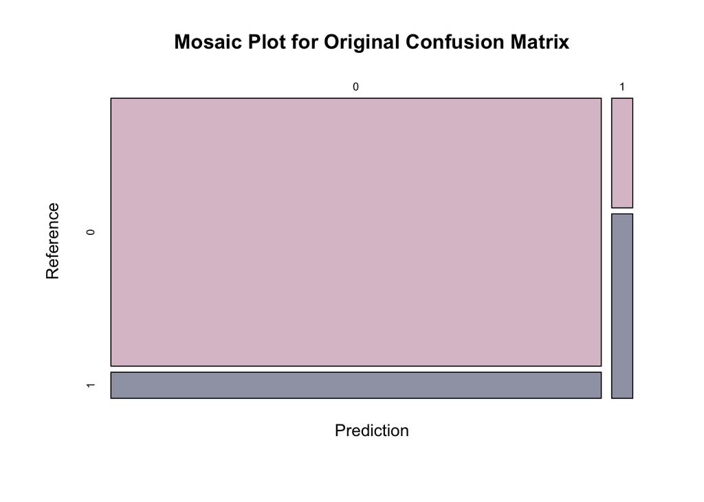

```r
testProbs <- data.frame(Outcome = as.factor(housingTest$y_numeric),
                        Probs = predict(housingModel, housingTest, type= "response"))

testProbs <-
  testProbs %>%
  mutate(predOutcome  = as.factor(ifelse(testProbs$Probs > 0.5 , 1, 0)))


mosaicplot(confusionMatrix(testProbs$predOutcome, testProbs$Outcome,
                       positive = "1")$table, color=c("#DBC2CF","#9FA2B2"), main = "Mosaic Plot for Original Confusion Matrix",
           xlab = "Prediction", ylab = "Reference")
```

```r
housingmatrix <- as.data.frame(as.table(confusionMatrix(testProbs$predOutcome, testProbs$Outcome,
                       positive = "1")$table))
housingmatrix %>%
  kable() %>%
  kable_styling(bootstrap_options = c("striped", "hover", "condensed"))  %>%
  footnote(general_title = "\n", general = "Table 4")
```

| Prediction | Reference | Freq |
| --- | --- | --- |
| 0 | 0 | 1251 |
| 1 | 0 | 22 |
| 0 | 1 | 122 |
| 1 | 1 | 37 |

Table 4

# Improving Model

However, just because a variable is significant at predicting credit acceptance does not mean that it is a relevant or meaningful predictor. To improve this model, not only do we need to perform feature engineering to increase sensitivity while maintain overall accuracy, but also do we need to exclude irrelevant features. To fit a new model:

```r
housing <- housing %>%
  mutate(edu = case_when(
    education == "high.school" | education == "professional.course" | education == "university.degree" ~ "highschool.above",
    TRUE ~ "highschool.below"),
    employment = case_when(
      job == "self-employed" ~ "self-employed",
      job == "retired" | job == "unemployed" | job == "student" | job == "unknown" | job == "housemaid" ~ "not-employed",
      job == "blue-collar" ~ "blue-collar",
      TRUE ~ "white-collar"))

housing$job_education_interaction <- paste(housing$edu, housing$employment, sep="_")
housing$campaign_efficiency <- housing$previous / housing$campaign
housing$economic_conditions <- (housing$unemploy_rate + housing$cons.price.idx + housing$cons.conf.idx - housing$inflation_rate) / 4
imbalance_weight <- sum(housing$y_numeric == 0) / sum(housing$y_numeric == 1)
```

Our improved model shows that most indicators are significantly correlated with credit acceptance with p < 0.05, except for some categories of job-education interaction as well as `pdays`, which is whether an individual has been contacted before. This is probably because `pday` is correlated with `poutcome`, another variable indicating success of previous contact.

```r
set.seed(479)
trainIndex <- createDataPartition(housing$y , p = .65,
                                  list = FALSE,
                                  times = 1)
housingTrain <- housing[ trainIndex,]
housingTest  <- housing[-trainIndex,]

improvedModel <- glm(y_numeric ~ .,
                  data=housingTrain %>%
                    dplyr::select(y_numeric, age, job_education_interaction, mortgage, pdays, contact, poutcome, economic_conditions, previous, campaign_efficiency),  weights = ifelse(y_numeric == 1, imbalance_weight, 1),
                  family="binomial" (link="logit"))

improved_sum <- summary(improvedModel)
coefficients_table <- as.data.frame(improved_sum$coefficients)

coefficients_table$significance <- ifelse(coefficients_table$`Pr(>|z|)` < 0.001, '***',
                                         ifelse(coefficients_table$`Pr(>|z|)` < 0.01, '**',
                                                ifelse(coefficients_table$`Pr(>|z|)` < 0.05, '*',
                                                       ifelse(coefficients_table$`Pr(>|z|)` < 0.1, '.', ''))))

coefficients_table$p_value <- paste0(round(coefficients_table$`Pr(>|z|)`, digits = 3), coefficients_table$significance)

coefficients_table %>%
  select(-significance, -`Pr(>|z|)`) %>%
  kable(align = "r") %>%
  kable_styling(bootstrap_options = c("striped", "hover", "condensed"))  %>%
  footnote(general_title = "\n", general = "Table 5")
```

|  | Estimate | Std. Error | z value | p_value |
| --- | --- | --- | --- | --- |
| (Intercept) | -2.4483602 | 0.4237519 | -5.7778149 | 0*** |
| age | 0.0067819 | 0.0029976 | 2.2624372 | 0.024* |
| job_education_interactionhighschool.above_not-employed | 0.5082476 | 0.2026669 | 2.5077973 | 0.012* |
| job_education_interactionhighschool.above_self-employed | -0.0568971 | 0.2457110 | -0.2315608 | 0.817 |
| job_education_interactionhighschool.above_white-collar | 0.0943712 | 0.1708588 | 0.5523346 | 0.581 |
| job_education_interactionhighschool.below_blue-collar | -0.1894807 | 0.1833597 | -1.0333825 | 0.301 |
| job_education_interactionhighschool.below_not-employed | 0.6054083 | 0.2088516 | 2.8987492 | 0.004** |
| job_education_interactionhighschool.below_self-employed | -0.8584100 | 0.4391580 | -1.9546725 | 0.051. |
| job_education_interactionhighschool.below_white-collar | -0.1024480 | 0.2011602 | -0.5092856 | 0.611 |
| mortgageunknown | -0.4819300 | 0.2161021 | -2.2301038 | 0.026* |
| mortgageyes | -0.1803795 | 0.0638614 | -2.8245484 | 0.005** |
| pdaysYes | 0.7306544 | 0.4883692 | 1.4961108 | 0.135 |
| contacttelephone | -0.8533536 | 0.0753342 | -11.3275664 | 0*** |
| poutcomenonexistent | 0.8229103 | 0.2266384 | 3.6309397 | 0*** |
| poutcomesuccess | 1.3750342 | 0.5028598 | 2.7344284 | 0.006** |
| economic_conditions | 0.1140043 | 0.0269205 | 4.2348516 | 0*** |
| previous | 1.1581184 | 0.2597144 | 4.4591994 | 0*** |
| campaign_efficiency | -0.4983248 | 0.2125183 | -2.3448563 | 0.019* |

Table 5

We tested our model and a mosaic plot is created to visualize the confusion matrix. Now, the model has much higher sensitivity rate of **0.61**. The accuracy rate dropped to **0.70**, but is still acceptable. This means that now, our model is able to capture a significantly more number of positive cases.

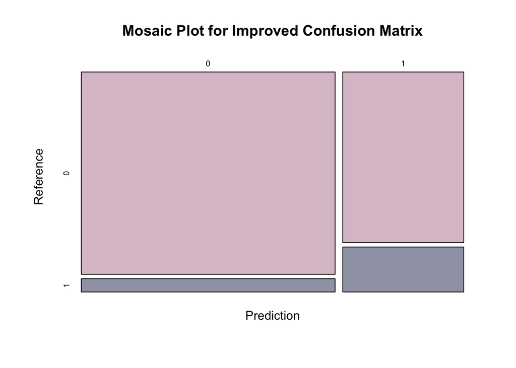

```r
testProbs <- data.frame(Outcome = as.factor(housingTest$y_numeric),
                        Probs = predict(improvedModel, housingTest, type= "response"))

testProbs <-
  testProbs %>%
  mutate(predOutcome  = as.factor(ifelse(testProbs$Probs > 0.5 , 1, 0)))


mosaicplot(confusionMatrix(testProbs$predOutcome, testProbs$Outcome,
                       positive = "1")$table, color=c("#DBC2CF","#9FA2B2"), main = "Mosaic Plot for Improved Confusion Matrix",
           xlab = "Prediction", ylab = "Reference")
```

```r
improvedmatrix <- as.data.frame(as.table(confusionMatrix(testProbs$predOutcome, testProbs$Outcome,
                       positive = "1")$table))

improvedmatrix %>%
  kable() %>%
  kable_styling(bootstrap_options = c("striped", "hover", "condensed"))  %>%
  footnote(general_title = "\n", general = "Table 6")
```

| Prediction | Reference | Freq |
| --- | --- | --- |
| 0 | 0 | 915 |
| 1 | 0 | 368 |
| 0 | 1 | 60 |
| 1 | 1 | 97 |

Table 6

We computed the Area Under the Receiver Operating Characteristic Curve (AUC-ROC) metric to further evaluate the performance of our improved model. The AUC value ranges from 0 to 1, where 0.5 means a model with no discriminatory power (it performs as well as random chance), and 1 means a perfect model (it perfectly distinguishes between positive and negative cases).Generally, an AUC between 0.7 and 0.8 is considered acceptable and indicates a fair to good performance of the model. While there is room for improvement, a score of 0.74 suggests that the model is capturing important patterns in the data and making predictions better than random guessing.

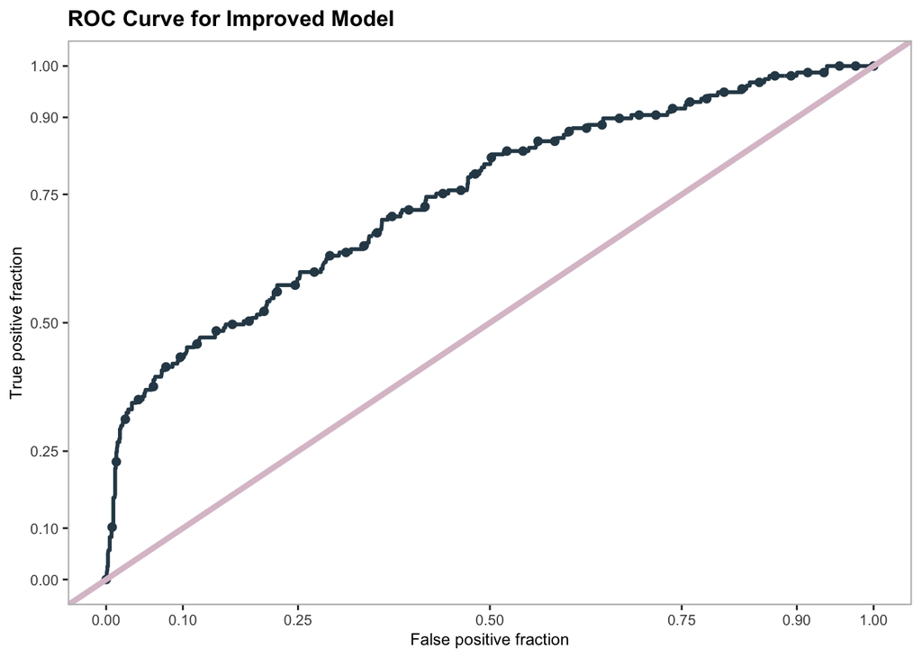

```r
ggplot(testProbs, aes(d = as.numeric(Outcome), m = Probs)) +
  geom_roc(n.cuts = 50, labels = FALSE, colour = "#2E4756") +
    labs(title = "ROC Curve for Improved Model") +
  style_roc(theme = theme_grey) +
  geom_abline(slope = 1, intercept = 0, size = 1.5, color = "#DBC2CF") +
  theme(plot.subtitle = element_text(size = 9,face = "italic"),
        plot.title = element_text(size = 12, face = "bold"),
        axis.text.x=element_text(size=8),
        axis.text.y=element_text(size=8),
        axis.title=element_text(size=9),
        panel.background = element_blank(),
        panel.border = element_rect(colour = "grey", fill=NA, linewidth =0.8))
```

# Cross Validation

```r
ctrl <- trainControl(method = "cv", number = 100, classProbs=TRUE, summaryFunction=twoClassSummary)

cvFit_original <- train(y ~ .,
                  data=housing %>%
                    dplyr::select(age, job, marital, education, taxLien, mortgage, taxbill_in_phl, contact, month, day_of_week, campaign, pdays, poutcome, unemploy_rate, cons.conf.idx, cons.price.idx, inflation_rate, spent_on_repairs, y),
                method="glm", family="binomial",

                             metric="ROC", trControl = ctrl)
cvFit_improved <- train(y ~ .,
                  data=housing %>%
                    dplyr::select(y, age, job_education_interaction, mortgage, pdays, contact, poutcome, economic_conditions, previous, campaign_efficiency),   weights = ifelse(y == "Yes", imbalance_weight, 1),
                method="glm", family="binomial",
                metric="ROC", trControl = ctrl)
```

The figure below plots the distribution of AUC, Sensitivity, and Specificity across the 100 folds. The tighter each distribution is to its mean, the more generalizable the model. Both models generalizes well to sensitivity – the rate it correctly predicts credit acceptance, instead of specificity. It seems our would-be decision-making tool is inconsistent in how it predicts the credit acceptance. This inconsistency will have a direct effect on the marketing and resource allocation process should this algorithm be put into production.

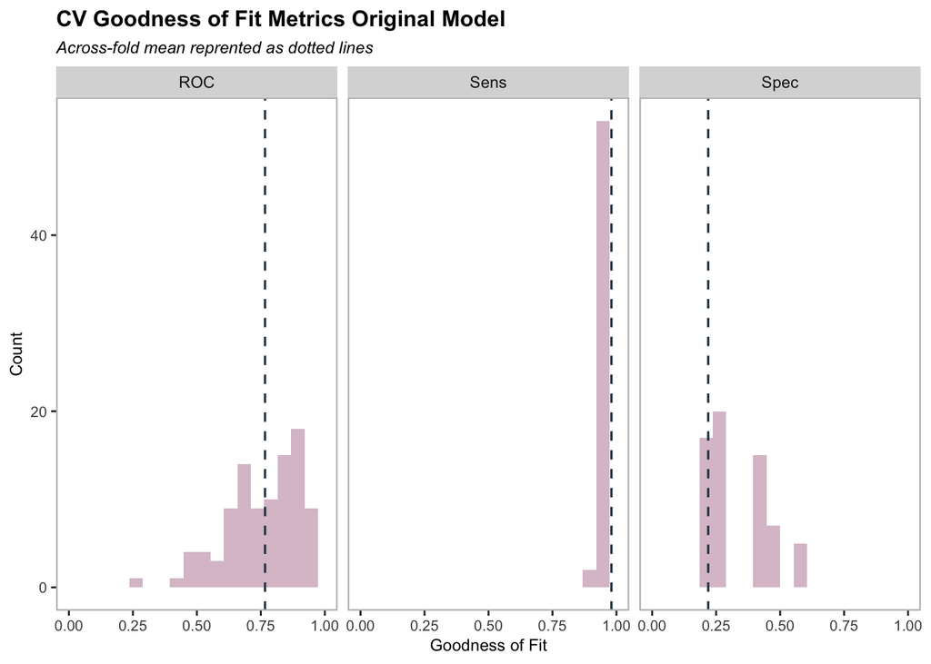

```r
dplyr::select(cvFit_original$resample, -Resample) %>%
  gather(metric, value) %>%
  left_join(gather(cvFit_original$results[2:4], metric, mean)) %>%
  ggplot(aes(value)) +
    geom_histogram(bins=20, fill = "#DBC2CF") +
    facet_wrap(~metric) +
    geom_vline(aes(xintercept = mean), colour = "#2E4756", linetype = 2, size = 0.6) +
    scale_x_continuous(limits = c(0, 1)) +
    labs(x="Goodness of Fit", y="Count", title="CV Goodness of Fit Metrics Original Model",
         subtitle = "Across-fold mean reprented as dotted lines") +
   theme(plot.subtitle = element_text(size = 9,face = "italic"),
        plot.title = element_text(size = 12, face = "bold"),
        axis.text.x=element_text(size=8),
        axis.text.y=element_text(size=8),
        axis.title=element_text(size=9),
        panel.background = element_blank(),
        panel.border = element_rect(colour = "grey", fill=NA, linewidth =0.8))
```

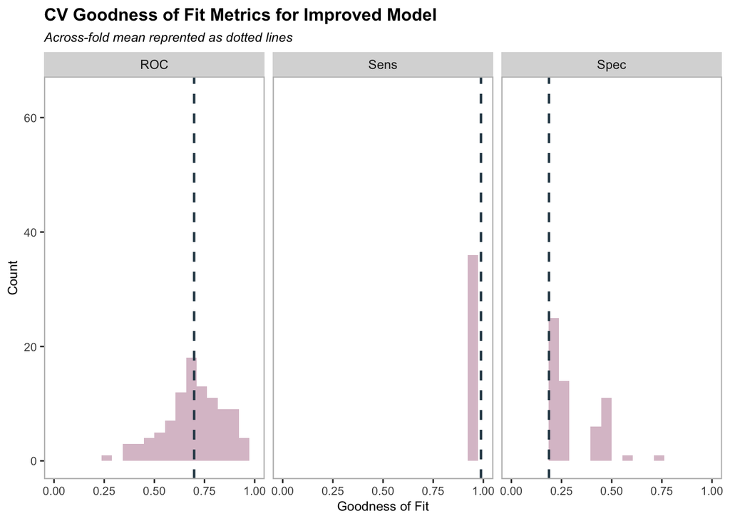

```r
dplyr::select(cvFit_improved$resample, -Resample) %>%
  gather(metric, value) %>%
  left_join(gather(cvFit_improved$results[2:4], metric, mean)) %>%
  ggplot(aes(value)) +
    geom_histogram(bins=20, fill = "#DBC2CF") +
    facet_wrap(~metric) +
    geom_vline(aes(xintercept = mean), colour = "#2E4756", linetype = 2, size = 0.8) +
    scale_x_continuous(limits = c(0, 1)) +
    labs(x="Goodness of Fit", y="Count", title="CV Goodness of Fit Metrics for Improved Model",
         subtitle = "Across-fold mean reprented as dotted lines") +
  theme(plot.subtitle = element_text(size = 9,face = "italic"),
        plot.title = element_text(size = 12, face = "bold"),
        axis.text.x=element_text(size=8),
        axis.text.y=element_text(size=8),
        axis.title=element_text(size=9),
        panel.background = element_blank(),
        panel.border = element_rect(colour = "grey", fill=NA, linewidth =0.8))
```

# Cost Benefit Analysis

In this final section, we conducted a cost benefit analysis to help HCD maximize their revenue. If we predict that a household will take the credit, then HCD allocates (on average) $2,850 per homeowner which includes staff and resources to facilitate mailers, phone calls, and information/counseling sessions at the HCD offices. And among those eligible homeowners, 25% of them will take the $5000 credit. This wil lead to a $10,000 premium, on average, for each houses that transacted after taking the credit and an aggregate premium of $56,000, on average, for homes surrounding the repaired home. Based on this, we outlined the cost/benefit for each scenario in the confusion matrix, where `Count` refers to the number of occurrences of each scenario:

- **True Positive**: We predicted correctly homeowner would enter credit program; allocated the marketing resources, and 25% ultimately achieved the credit: $-2850 * Count - 5000 * Count * 0.25 + (10000 + 56000) * Count$
- **True Negative**: We predicted correctly homeowner would not take the credit, no marketing resources were allocated, and no credit was allocated: $0*Count$
- **False Positive**: We predicted incorrectly homeowner would take the credit; allocated marketing resources; no credit allocated: $-2850 * Count$
- **False Negative**: We predicted that a homeowner would not take the credit but they did. These are likely homeowners who signed up for reasons unrelated to the marketing campaign. Thus, we ‘0 out’ this category.

```r
cost_benefit_table <-
   testProbs %>%
      count(predOutcome, Outcome) %>%
      summarize(True_Negative = sum(n[predOutcome==0 & Outcome==0]),
                True_Positive = sum(n[predOutcome==1 & Outcome==1]),
                False_Negative = sum(n[predOutcome==0 & Outcome==1]),
                False_Positive = sum(n[predOutcome==1 & Outcome==0])) %>%
       gather(Variable, Count) %>%
       mutate(Revenue =
               ifelse(Variable == "True_Negative", Count * 0,
               ifelse(Variable == "True_Positive", 61900 * Count,
               ifelse(Variable == "False_Negative", 0 * Count,
               ifelse(Variable == "False_Positive", (-2850) * Count, 0)))))

kable(cost_benefit_table) %>%
kable_styling(bootstrap_options = c("striped", "hover", "condensed"))  %>%
  footnote(general_title = "\n", general = "Table 7")
```

| Variable | Count | Revenue |
| --- | --- | --- |
| True_Negative | 915 | 0 |
| True_Positive | 97 | 6004300 |
| False_Negative | 60 | 0 |
| False_Positive | 368 | -1048800 |

Table 7

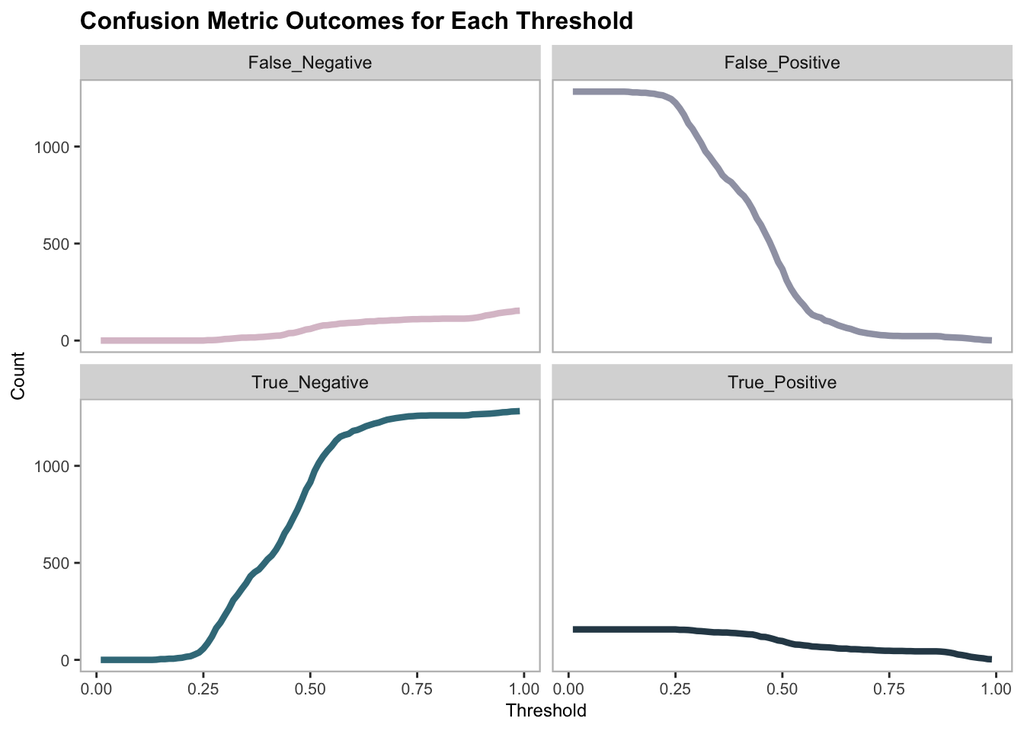

```r
all_threshold %>%
  ggplot() +
  geom_line(aes(x = threshold, y=Count, color = Variable), size = 1.5, linetype = 1) +
  scale_color_manual(values = palette4, guide=FALSE) +
  facet_wrap(~Variable) +
  labs(title = "Confusion Metric Outcomes for Each Threshold") +
  xlab("Threshold") +
  theme(plot.subtitle = element_text(size = 9,face = "italic"),
        plot.title = element_text(size = 12, face = "bold"),
        axis.text.x=element_text(size=8),
        axis.text.y=element_text(size=8),
        axis.title=element_text(size=9),
        panel.background = element_blank(),
        panel.border = element_rect(colour = "grey", fill=NA, linewidth =0.8))
```

The `iterateThresholds` function is based on a while loop. The threshold x, starts at 0.01 and while it is less than 1, a predicted classification, predOutcome, is mutated given x; confusion metrics are calculated; the cost benefit is performed and is appended to a data frame called all_prediction. Finally x is iterated by adding 0.01 and the process continues until x = 1.

```r
iterateThresholds <- function(data) {
  x = .01
  all_prediction <- data.frame()
  while (x <= 1) {

  this_prediction <-
      testProbs %>%
      mutate(predOutcome = ifelse(Probs > x, 1, 0)) %>%
      count(predOutcome, Outcome) %>%
      summarize(True_Negative = sum(n[predOutcome==0 & Outcome==0]),
                True_Positive = sum(n[predOutcome==1 & Outcome==1]),
                False_Negative = sum(n[predOutcome==0 & Outcome==1]),
                False_Positive = sum(n[predOutcome==1 & Outcome==0])) %>%
     gather(Variable, Count) %>%
     mutate(Revenue =
               ifelse(Variable == "True_Negative", Count * 0,
               ifelse(Variable == "True_Positive", 61900 * Count,
               ifelse(Variable == "False_Negative", 0 * Count,
               ifelse(Variable == "False_Positive", (-2850) * Count, 0)))),
            Threshold = x)

  all_prediction <- rbind(all_prediction, this_prediction)
  x <- x + .01
  }
return(all_prediction)
}
```

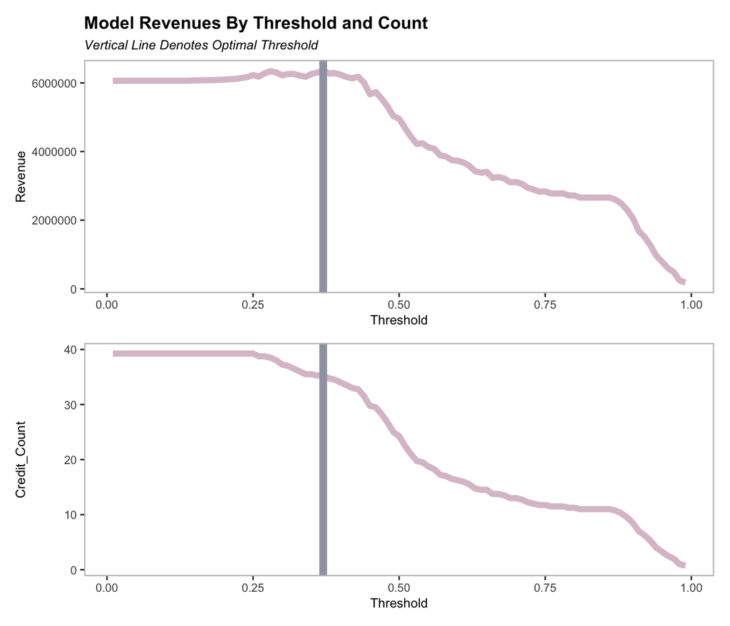

```r
whichThreshold <- iterateThresholds(testProbs)

whichThreshold_revenue <-
whichThreshold %>%
    group_by(Threshold) %>%
    summarize(Revenue = sum(Revenue))

plot1 <- ggplot(whichThreshold_revenue)+
  geom_line(aes(x = Threshold, y = Revenue), linewidth = 2, color = "#DBC2CF")+
  geom_vline(xintercept =  pull(arrange(whichThreshold_revenue, -Revenue)[1,1]), color = "#9FA2B2", linewidth = 2.5)+
    labs(title = "Model Revenues By Threshold and Count",
         subtitle = "Vertical Line Denotes Optimal Threshold") +
  theme(plot.subtitle = element_text(size = 9,face = "italic"),
        plot.title = element_text(size = 12, face = "bold"),
        axis.text.x=element_text(size=8),
        axis.text.y=element_text(size=8),
        axis.title=element_text(size=9),
        panel.background = element_blank(),
        panel.border = element_rect(colour = "grey", fill=NA, linewidth =0.8))

credict_count <-whichThreshold %>%
  filter(Variable == "True_Positive") %>%
  mutate(Credit_Count = Count * 0.25)

plot2 <- credict_count %>%
  ggplot() +
  geom_line(aes(x = Threshold, y = Credit_Count), linewidth = 2, color = "#DBC2CF") +
  geom_vline(xintercept =  pull(arrange(whichThreshold_revenue, -Revenue)[1,1]), color = "#9FA2B2", linewidth = 2.5) +
   theme(plot.subtitle = element_text(size = 9,face = "italic"),
        plot.title = element_text(size = 12, face = "bold"),
        axis.text.x=element_text(size=8),
        axis.text.y=element_text(size=8),
        axis.title=element_text(size=9),
        panel.background = element_blank(),
        panel.border = element_rect(colour = "grey", fill=NA, linewidth =0.8))

plot1 / plot2
```

```r
final_table<- data.frame(
  Threshold = c("Optimal_Threshold", "50%_Threshold"),
  Credit = c("34.75", "23.75"),
  Revenue = c("6403900", "4817450")
)

final_table %>%
  kbl() %>%
  kable_styling(bootstrap_options = c("striped", "hover", "condensed"))  %>%
  footnote(general_title = "\n", general = "Table 8")
```

[output not shown]

Table 8

# Conclusions

In conclusion, we have designed a model to predict the likelihood of Emil City homeowners accepting home repair tax credit with acceptable accuracy and sensitivity, but this does not mean that this model can be put into production at this point. Our primary concerns with the model include the following. Firstly, there’s significant discrepancies in terms of the number of outcomes of our predictor variables. In logistic regression, unbalanced sample sizes can lead the model to be biased towards the majority class. If the minority class is of particular interest (in our case, people who accepted the credit is the minority class), an unbalanced data set can result in poor predictive performance for the minority class, leading to a model with high accuracy because it predicts the majority class well, but performs poorly on the minority class. Despite that we have applied weight on our minority class to alleviate the effect of imbalanced dataset, it will be good to either oversample the minority class, undersample the majority class, or use alternative algorithm approaches to assign different classifications costs to different classes.

In addition, the current data set contains a lot of field categorized as unknown, and sometimes we see a statistically significant differences in mean between our unknown group and other group in a paired wise comparison. This is leading to misinterpretation in our results. In most cases, models are the most accurate when built using previous data on credit acceptance, and having unknown fields in these variables is likely lead to poor performance of our model.

Moreover, human behavior is influenced by a myriad of factors, including emotions, culture, social norms, personal experiences, and cognitive processes, and those dimensions are not fully included in our model. While capturing this complexity of human behavior in a mathematical model is inherently challenging, it is good practice to include variables such as lifestyle choices, emotional state, device usage, and most importantly, results from any feedback surveys into this model.

And finally, we need to think about what is the most “optimal” model for HCD. For organizations whose goal is solely to achieve greater economic benefits, than we have provided an optimized model for them. But for government agencies like HCD who has many unquantifiable bottom lines like equity and social cohesion, this might not be the case. Whether or not to allocated credit and to whom they allcoate credit should not be based entirely on revenues made, but on people who need those resources.